# Customer Segmentation Project

Segmenting customers based on **behavior** and **demographics** using K-Means clustering, to enable targeted marketing and personalized business strategy.

**Approach:** Load customer data → explore it → scale features → find the optimal number of clusters (Elbow + Silhouette methods) → run K-Means → visualize and profile each segment → assign business-friendly names to each segment.

## 1. Setup & Imports

```python
import pandas as pd
import numpy as np
import matplotlib.pyplot as plt
import seaborn as sns
from sklearn.preprocessing import StandardScaler
from sklearn.cluster import KMeans
from sklearn.metrics import silhouette_score
from sklearn.decomposition import PCA

sns.set_style("whitegrid")
plt.rcParams["figure.dpi"] = 110
pd.set_option("display.max_columns", None)
```

## 2. Load the Data

The dataset contains **515 customers** with demographic and behavioral attributes:

| Column | Description |
| --- | --- |
| `CustomerID` | Unique customer identifier |
| `Age` | Customer age |
| `Gender` | Customer gender |
| `Annual_Income_Lakhs` | Annual income (₹ Lakhs) |
| `Spending_Score` | Score (1–100) assigned based on spending behavior |
| `Purchase_Frequency` | Number of orders placed per year |
| `Recency_Days` | Days since the customer's last purchase |
| `Preferred_Category` | Product category the customer buys most |

```python
df = pd.read_csv("customer_data.csv")
print(df.shape)
df.head()
```

```
(515, 8)
```

|  | CustomerID | Age | Gender | Annual_Income_Lakhs | Spending_Score | Purchase_Frequency | Recency_Days | Preferred_Category |
| --- | --- | --- | --- | --- | --- | --- | --- | --- |
| 0 | CUST1490 | 53 | Female | 9.0 | 59 | 9 | 58 | Beauty |
| 1 | CUST1430 | 26 | Male | 5.8 | 51 | 9 | 45 | Sports |
| 2 | CUST1083 | 35 | Male | 16.9 | 89 | 21 | 20 | Beauty |
| 3 | CUST1121 | 44 | Male | 22.2 | 29 | 6 | 42 | Fashion |
| 4 | CUST1222 | 21 | Female | 8.3 | 74 | 12 | 23 | Groceries |

## 3. Exploratory Data Analysis

```python
df.describe()
```

|  | Age | Annual_Income_Lakhs | Spending_Score | Purchase_Frequency | Recency_Days |
| --- | --- | --- | --- | --- | --- |
| count | 515.000000 | 515.000000 | 515.000000 | 515.000000 | 515.000000 |
| mean | 36.304854 | 10.574369 | 53.704854 | 12.877670 | 51.605825 |
| std | 9.536448 | 5.981684 | 25.677631 | 8.432531 | 44.642266 |
| min | 18.000000 | 1.500000 | 5.000000 | 1.000000 | 1.000000 |
| 25% | 29.000000 | 5.300000 | 28.000000 | 5.000000 | 15.500000 |
| 50% | 36.000000 | 8.800000 | 56.000000 | 12.000000 | 31.000000 |
| 75% | 43.000000 | 16.050000 | 77.000000 | 20.000000 | 91.000000 |
| max | 64.000000 | 26.700000 | 100.000000 | 33.000000 | 180.000000 |

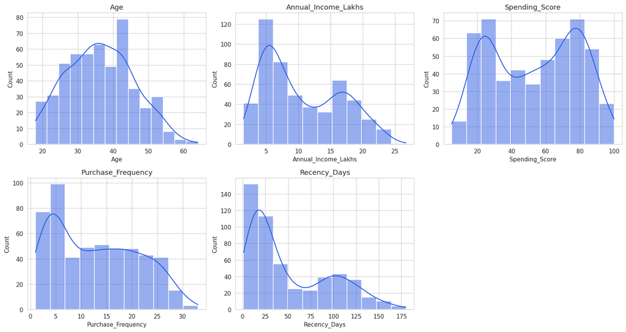

```python
fig, axes = plt.subplots(2, 3, figsize=(15, 8))
num_cols = ["Age", "Annual_Income_Lakhs", "Spending_Score", "Purchase_Frequency", "Recency_Days"]
for ax, col in zip(axes.flat, num_cols):
    sns.histplot(df[col], kde=True, ax=ax, color="#2F5CE0")
    ax.set_title(col)
axes.flat[-1].axis("off")
plt.tight_layout()
plt.savefig("plots/01_distributions.png", bbox_inches="tight")
plt.show()
```

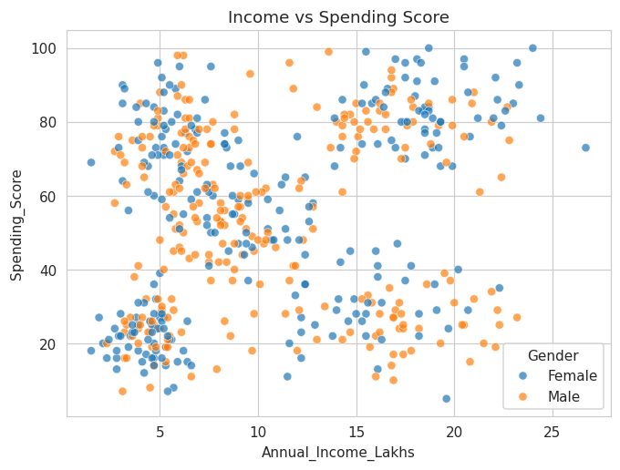

```python
plt.figure(figsize=(7, 5))
sns.scatterplot(data=df, x="Annual_Income_Lakhs", y="Spending_Score", hue="Gender", alpha=0.7)
plt.title("Income vs Spending Score")
plt.savefig("plots/02_income_vs_spending.png", bbox_inches="tight")
plt.show()
```

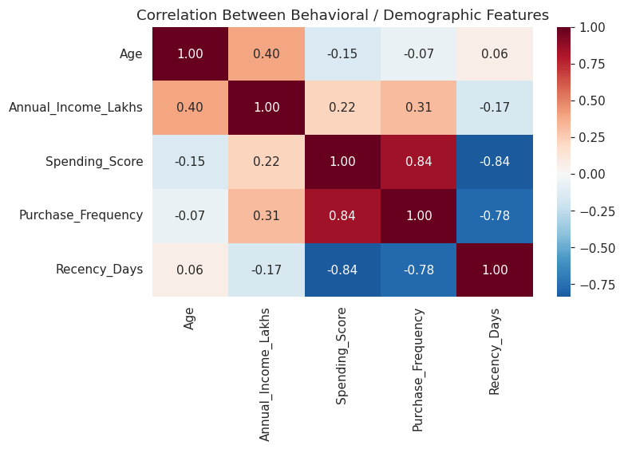

```python
plt.figure(figsize=(7, 4))
corr = df[num_cols].corr()
sns.heatmap(corr, annot=True, cmap="RdBu_r", center=0, fmt=".2f")
plt.title("Correlation Between Behavioral / Demographic Features")
plt.savefig("plots/03_correlation.png", bbox_inches="tight")
plt.show()
```

## 4. Feature Scaling

K-Means is distance-based, so features on different scales (e.g. Age in years vs Income in Lakhs) must be **standardized** before clustering, otherwise high-magnitude features would dominate the distance calculation.

```python
features = ["Age", "Annual_Income_Lakhs", "Spending_Score", "Purchase_Frequency", "Recency_Days"]
X = df[features].copy()

scaler = StandardScaler()
X_scaled = scaler.fit_transform(X)
X_scaled = pd.DataFrame(X_scaled, columns=features)
X_scaled.head()
```

|  | Age | Annual_Income_Lakhs | Spending_Score | Purchase_Frequency | Recency_Days |
| --- | --- | --- | --- | --- | --- |
| 0 | 1.752369 | -0.263454 | 0.206417 | -0.460294 | 0.143371 |
| 1 | -1.081626 | -0.798941 | -0.105441 | -0.460294 | -0.148116 |
| 2 | -0.136961 | 1.058528 | 1.375885 | 0.964150 | -0.708668 |
| 3 | 0.807704 | 1.945428 | -0.963051 | -0.816405 | -0.215383 |
| 4 | -1.606440 | -0.380592 | 0.791151 | -0.104183 | -0.641402 |

## 5. Finding the Optimal Number of Clusters

Two standard techniques are used together:

- **Elbow Method** — plots inertia (within-cluster variance) vs k; look for the point where the drop levels off
- **Silhouette Score** — measures how well-separated the clusters are (higher is better, range -1 to 1)

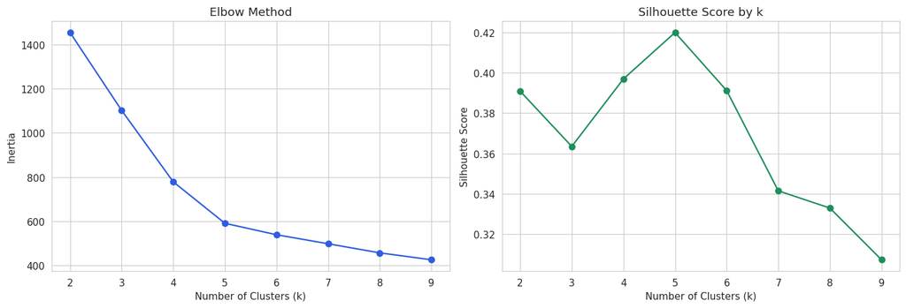

```
Best k by silhouette score: 5
```

```python
inertias = []
silhouettes = []
K_range = range(2, 10)

for k in K_range:
    km = KMeans(n_clusters=k, random_state=42, n_init=10)
    labels = km.fit_predict(X_scaled)
    inertias.append(km.inertia_)
    silhouettes.append(silhouette_score(X_scaled, labels))

fig, axes = plt.subplots(1, 2, figsize=(13, 4.5))
axes[0].plot(list(K_range), inertias, marker="o", color="#2F5CE0")
axes[0].set_title("Elbow Method")
axes[0].set_xlabel("Number of Clusters (k)")
axes[0].set_ylabel("Inertia")

axes[1].plot(list(K_range), silhouettes, marker="o", color="#1E8E5A")
axes[1].set_title("Silhouette Score by k")
axes[1].set_xlabel("Number of Clusters (k)")
axes[1].set_ylabel("Silhouette Score")
plt.tight_layout()
plt.savefig("plots/04_elbow_silhouette.png", bbox_inches="tight")
plt.show()

best_k = list(K_range)[int(np.argmax(silhouettes))]
print(f"Best k by silhouette score: {best_k}")
```

## 6. Fit Final K-Means Model

Based on the elbow and silhouette results, we fit the final model with the chosen number of clusters and assign each customer to a segment.

```python
k = best_k  # chosen from the analysis above
kmeans = KMeans(n_clusters=k, random_state=42, n_init=10)
df["Cluster"] = kmeans.fit_predict(X_scaled)

print(f"Number of segments: {k}")
df["Cluster"].value_counts().sort_index()
```

```
Number of segments: 5
```

```
Cluster
0    107
1     99
2    132
3     88
4     89
Name: count, dtype: int64
```

## 7. Visualizing the Segments (PCA 2D Projection)

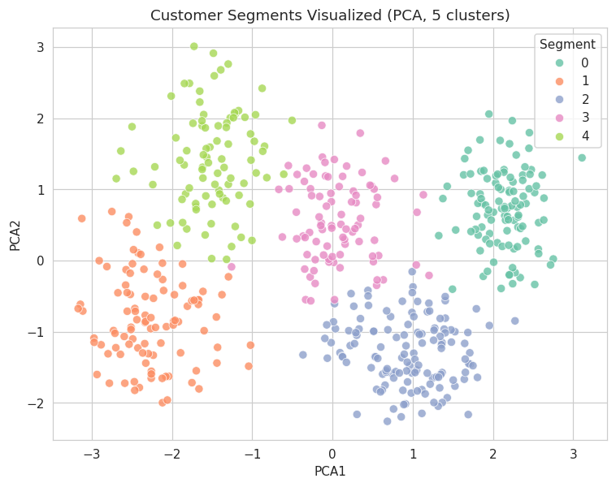

```
Variance explained by 2 PCA components: 82.5%
```

```python
pca = PCA(n_components=2, random_state=42)
pca_coords = pca.fit_transform(X_scaled)
df["PCA1"], df["PCA2"] = pca_coords[:, 0], pca_coords[:, 1]

plt.figure(figsize=(8, 6))
palette = sns.color_palette("Set2", n_colors=k)
sns.scatterplot(data=df, x="PCA1", y="PCA2", hue="Cluster", palette=palette, s=45, alpha=0.8)
plt.title(f"Customer Segments Visualized (PCA, {k} clusters)")
plt.legend(title="Segment")
plt.savefig("plots/05_pca_clusters.png", bbox_inches="tight")
plt.show()

print(f"Variance explained by 2 PCA components: {pca.explained_variance_ratio_.sum():.1%}")
```

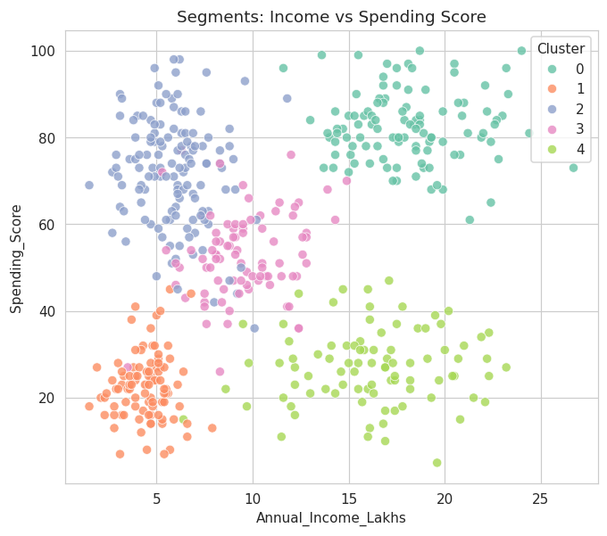

```python
plt.figure(figsize=(7, 6))
sns.scatterplot(data=df, x="Annual_Income_Lakhs", y="Spending_Score", hue="Cluster", palette=palette, s=45, alpha=0.8)
plt.title("Segments: Income vs Spending Score")
plt.savefig("plots/06_income_spending_clusters.png", bbox_inches="tight")
plt.show()
```

## 8. Profiling Each Segment

```python
segment_profile = df.groupby("Cluster")[features].mean().round(1)
segment_profile["Customer_Count"] = df["Cluster"].value_counts().sort_index()
segment_profile
```

| Cluster | Age | Annual_Income_Lakhs | Spending_Score | Purchase_Frequency | Recency_Days | Customer_Count |
| --- | --- | --- | --- | --- | --- | --- |
| 0 | 37.6 | 18.1 | 82.4 | 23.9 | 12.3 | 107 |
| 1 | 31.1 | 4.5 | 22.7 | 3.1 | 109.5 | 99 |
| 2 | 28.2 | 5.9 | 72.1 | 17.0 | 20.4 | 132 |
| 3 | 45.3 | 9.5 | 52.9 | 12.0 | 34.1 | 88 |
| 4 | 43.7 | 16.2 | 27.1 | 5.3 | 98.1 | 89 |

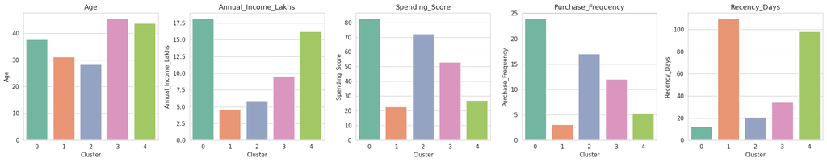

```python
fig, axes = plt.subplots(1, len(features), figsize=(20, 4))
for ax, col in zip(axes, features):
    sns.barplot(data=segment_profile.reset_index(), x="Cluster", y=col, ax=ax, palette=palette)
    ax.set_title(col)
plt.tight_layout()
plt.savefig("plots/07_segment_profiles.png", bbox_inches="tight")
plt.show()
```

```python
top_category = df.groupby("Cluster")["Preferred_Category"].agg(lambda x: x.value_counts().idxmax())
top_category.name = "Top_Category"
segment_profile = segment_profile.join(top_category)
segment_profile
```

| Cluster | Age | Annual_Income_Lakhs | Spending_Score | Purchase_Frequency | Recency_Days | Customer_Count | Top_Category |
| --- | --- | --- | --- | --- | --- | --- | --- |
| 0 | 37.6 | 18.1 | 82.4 | 23.9 | 12.3 | 107 | Sports |
| 1 | 31.1 | 4.5 | 22.7 | 3.1 | 109.5 | 99 | Beauty |
| 2 | 28.2 | 5.9 | 72.1 | 17.0 | 20.4 | 132 | Electronics |
| 3 | 45.3 | 9.5 | 52.9 | 12.0 | 34.1 | 88 | Sports |
| 4 | 43.7 | 16.2 | 27.1 | 5.3 | 98.1 | 89 | Home & Kitchen |

## 9. Naming the Segments

Based on the average characteristics of each cluster, we assign business-friendly names. **This step is manual/interpretive** — a data scientist looks at the profile table above and translates numbers into a segment story that a marketing team can act on.

Update the `segment_names` dictionary below to match the clusters your run actually produces (cluster numbers can vary run to run).

```python
# Inspect the profile table above, then map each cluster number to a name.
# Example logic: high income + high spending -> "Premium Loyalists", etc.
segment_profile_sorted = segment_profile.sort_values("Spending_Score", ascending=False)
print(segment_profile_sorted)

segment_names = {}
for cluster_id, row in segment_profile.iterrows():
    if row["Annual_Income_Lakhs"] > segment_profile["Annual_Income_Lakhs"].median() and row["Spending_Score"] > segment_profile["Spending_Score"].median():
        segment_names[cluster_id] = "Premium Loyalists"
    elif row["Annual_Income_Lakhs"] > segment_profile["Annual_Income_Lakhs"].median() and row["Spending_Score"] <= segment_profile["Spending_Score"].median():
        segment_names[cluster_id] = "Affluent Disengaged"
    elif row["Annual_Income_Lakhs"] <= segment_profile["Annual_Income_Lakhs"].median() and row["Spending_Score"] > segment_profile["Spending_Score"].median():
        segment_names[cluster_id] = "Budget Enthusiasts"
    elif row["Recency_Days"] > segment_profile["Recency_Days"].median():
        segment_names[cluster_id] = "Price-Sensitive / At Risk"
    else:
        segment_names[cluster_id] = "Steady Regulars"

df["Segment_Name"] = df["Cluster"].map(segment_names)
segment_profile["Segment_Name"] = segment_profile.index.map(segment_names)
segment_profile
```

```
          Age  Annual_Income_Lakhs  Spending_Score  Purchase_Frequency  \
Cluster
0        37.6                 18.1            82.4                23.9
2        28.2                  5.9            72.1                17.0
3        45.3                  9.5            52.9                12.0
4        43.7                 16.2            27.1                 5.3
1        31.1                  4.5            22.7                 3.1

         Recency_Days  Customer_Count    Top_Category
Cluster
0                12.3             107          Sports
2                20.4             132     Electronics
3                34.1              88          Sports
4                98.1              89  Home & Kitchen
1               109.5              99          Beauty
```

| Cluster | Age | Annual_Income_Lakhs | Spending_Score | Purchase_Frequency | Recency_Days | Customer_Count | Top_Category | Segment_Name |
| --- | --- | --- | --- | --- | --- | --- | --- | --- |
| 0 | 37.6 | 18.1 | 82.4 | 23.9 | 12.3 | 107 | Sports | Premium Loyalists |
| 1 | 31.1 | 4.5 | 22.7 | 3.1 | 109.5 | 99 | Beauty | Price-Sensitive / At Risk |
| 2 | 28.2 | 5.9 | 72.1 | 17.0 | 20.4 | 132 | Electronics | Budget Enthusiasts |
| 3 | 45.3 | 9.5 | 52.9 | 12.0 | 34.1 | 88 | Sports | Steady Regulars |
| 4 | 43.7 | 16.2 | 27.1 | 5.3 | 98.1 | 89 | Home & Kitchen | Affluent Disengaged |

## 10. Final Segment Summary & Recommendations

```python
summary = segment_profile[["Segment_Name", "Customer_Count", "Age", "Annual_Income_Lakhs",
                            "Spending_Score", "Purchase_Frequency", "Recency_Days", "Top_Category"]]
summary
```

| Cluster | Segment_Name | Customer_Count | Age | Annual_Income_Lakhs | Spending_Score | Purchase_Frequency | Recency_Days | Top_Category |
| --- | --- | --- | --- | --- | --- | --- | --- | --- |
| 0 | Premium Loyalists | 107 | 37.6 | 18.1 | 82.4 | 23.9 | 12.3 | Sports |
| 1 | Price-Sensitive / At Risk | 99 | 31.1 | 4.5 | 22.7 | 3.1 | 109.5 | Beauty |
| 2 | Budget Enthusiasts | 132 | 28.2 | 5.9 | 72.1 | 17.0 | 20.4 | Electronics |
| 3 | Steady Regulars | 88 | 45.3 | 9.5 | 52.9 | 12.0 | 34.1 | Sports |
| 4 | Affluent Disengaged | 89 | 43.7 | 16.2 | 27.1 | 5.3 | 98.1 | Home & Kitchen |

### Business Interpretation (example — adapt to your actual output)

- **Premium Loyalists** — high income, high spending, frequent buyers → prioritize retention (loyalty programs, early access to new products)
- **Affluent Disengaged** — high income but low engagement → win-back campaigns, personalized offers to re-activate
- **Budget Enthusiasts** — lower income but high spending score → value-driven promotions, bundle deals
- **Price-Sensitive / At Risk** — infrequent, high recency (haven't purchased recently) → discount-led re-engagement, reminder emails
- **Steady Regulars** — moderate across the board → maintain consistent engagement, upsell opportunities

*(Exact labels depend on the cluster numbers your run produces — see the printed `segment_profile_sorted` table above to map cluster IDs to the correct story.)*

```python
df.to_csv("customer_segments_output.csv", index=False)
print("Saved: customer_segments_output.csv")
```

```
Saved: customer_segments_output.csv
```